# april28_test

```python
from hcipy import (
    make_pupil_grid, make_focal_grid, make_circular_aperture,
    FraunhoferPropagator, make_zernike_basis, Wavefront, Field,
)
from skimage.transform import resize
from image_sharpening import FocusDiversePhaseRetrieval, mft_rev, InstrumentConfiguration
```

```python
import numpy as np
```

```python
seal_parameters = {
    'image_dx': 2.0071, 'focal_length_meters': 500e-3, 'wavelength_meter': 650e-9,
    'pupil_size': 10.12e-3, 'pupil_pixel_dimension': 256, 'q': 16, 'Num_airycircles': 16,
}
seal_param_config = {
    'image_dx':   seal_parameters['image_dx'],
    'efl':        seal_parameters['focal_length_meters'] * 1e3,
    'wavelength': seal_parameters['wavelength_meter'] * 1e6,
    'pupil_size': seal_parameters['pupil_size'] * 1e3,
}
WAVELENGTH_UM = seal_param_config['wavelength']
IMAGE_DX_UM   = seal_param_config['image_dx']

conf       = InstrumentConfiguration(seal_param_config)
pupil_grid = make_pupil_grid(seal_parameters['pupil_pixel_dimension'], seal_parameters['pupil_size'])
focal_grid = make_focal_grid(q=seal_parameters['q'], num_airy=seal_parameters['Num_airycircles'],
                             pupil_diameter=seal_parameters['pupil_size'],
                             focal_length=seal_parameters['focal_length_meters'],
                             reference_wavelength=seal_parameters['wavelength_meter'])
aperture        = make_circular_aperture(seal_parameters['pupil_size'])
telescope_pupil = aperture(pupil_grid)
pupil_mask      = np.array(telescope_pupil.shaped, dtype=bool)
prop_p2f        = FraunhoferPropagator(pupil_grid, focal_grid, seal_parameters['focal_length_meters'])
zernike_modes   = make_zernike_basis(num_modes=32, D=seal_parameters['pupil_size'], grid=pupil_grid)
defocus_tmpl    = zernike_modes[3]
```

```python
import numpy as np
import matplotlib.pyplot as plt
```

## Simulation Parameters

```python
A_WAVES    = 0.10       # sinusoid amplitude in waves
NU0        = 10         # spatial frequency, cycles per aperture
DZ_MM      = 40         # defocus diversity distance, mm
N_ITERS    = 150        # FDPR iterations
PHOTONS    = 1e6        # total photon count per PSF
READ_NOISE = 5.0        # e- read noise std

D          = seal_parameters['pupil_size']
wavelength = seal_parameters['wavelength_meter']
f_len      = seal_parameters['focal_length_meters']
rad_to_nm  = wavelength * 1e9 / (2 * np.pi)
```

## Build Truth Aberration and Defocus Diversity

```
Aberration amplitude : 0.10 waves  (65.0 nm RMS-ish)
Defocus scale factor : 5.716
Defocus P2V          : 19.80 rad  (2048 nm)
```

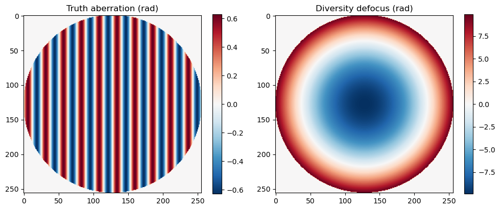

```python
# Sinusoidal aberration across the pupil (radians)
phi_ab = Field(A_WAVES * 2 * np.pi * np.sin(2 * np.pi * NU0 * pupil_grid.x / D), pupil_grid)

# Scale Zernike defocus template to match the requested DZ_MM
# delta = 8 * P * (f/D)^2  =>  P = delta / (8*(f/D)^2)  (meters)
p2v_tmpl     = float(np.max(defocus_tmpl) - np.min(defocus_tmpl))  # rad P2V of unit-Zernike
target_P_m   = abs(DZ_MM * 1e-3) / (8 * (f_len / D)**2)
target_P_rad = target_P_m * 2 * np.pi / wavelength
defocus_scale = target_P_rad / p2v_tmpl
phi_df = defocus_tmpl * defocus_scale

print(f"Aberration amplitude : {A_WAVES:.2f} waves  ({A_WAVES*2*np.pi*rad_to_nm:.1f} nm RMS-ish)")
print(f"Defocus scale factor : {defocus_scale:.3f}")
print(f"Defocus P2V          : {target_P_rad:.2f} rad  ({target_P_m*1e9:.0f} nm)")

# Quick-look: truth aberration inside the pupil
fig, axes = plt.subplots(1, 2, figsize=(10, 4))
im0 = axes[0].imshow(np.array(phi_ab.shaped) * np.array(telescope_pupil.shaped),
                      cmap='RdBu_r')
axes[0].set_title('Truth aberration (rad)'); plt.colorbar(im0, ax=axes[0])
im1 = axes[1].imshow(np.array(phi_df.shaped) * np.array(telescope_pupil.shaped),
                      cmap='RdBu_r')
axes[1].set_title('Diversity defocus (rad)'); plt.colorbar(im1, ax=axes[1])
plt.tight_layout()
```

## Generate PSFs (Focused + Diversity) with Noise

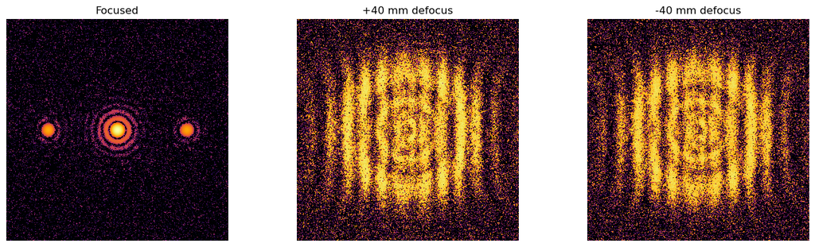

```python
def make_wf(phase_field):
    """Create a Wavefront with given phase applied to the telescope pupil."""
    wf = Wavefront(telescope_pupil, wavelength=wavelength)
    wf.electric_field = telescope_pupil * np.exp(1j * phase_field)
    return wf

def make_psf(phase_field):
    """Propagate phase to focal plane, return intensity as 2D numpy array."""
    focal = prop_p2f(make_wf(phase_field))
    return np.array(focal.intensity.shaped)

def add_noise(psf, total_photons, read_noise):
    """Add shot noise (Poisson) and Gaussian read noise."""
    scaled = psf / psf.sum() * total_photons
    shot = np.random.poisson(np.clip(scaled, 0, None).astype(float))
    noisy = shot + np.random.normal(0, read_noise, psf.shape)
    return np.clip(noisy, 0, None)

# Noiseless PSFs
psf_f_clean = make_psf(phi_ab)
psf_p_clean = make_psf(phi_ab + phi_df)
psf_m_clean = make_psf(phi_ab - phi_df)

# Noisy PSFs
np.random.seed(42)
psf_f = add_noise(psf_f_clean, PHOTONS, READ_NOISE)
psf_p = add_noise(psf_p_clean, PHOTONS, READ_NOISE)
psf_m = add_noise(psf_m_clean, PHOTONS, READ_NOISE)

# Quick-look
fig, axes = plt.subplots(1, 3, figsize=(14, 4))
for ax, img, title in zip(axes,
                           [psf_f, psf_p, psf_m],
                           ['Focused', f'+{DZ_MM} mm defocus', f'-{DZ_MM} mm defocus']):
    ax.imshow(np.log10(img / img.max() + 1e-12), vmin=-5, cmap='inferno')
    ax.set_title(title); ax.axis('off')
plt.tight_layout()
```

## Run FDPR

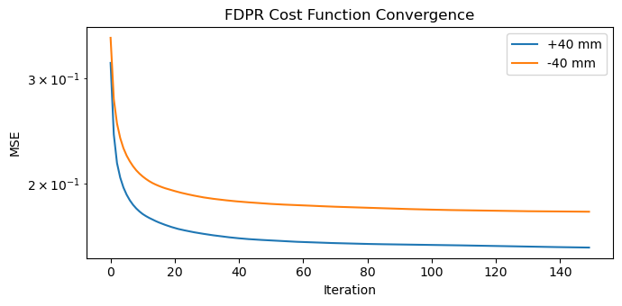

```python
DZ_UM = DZ_MM * 1e3  # mm -> microns for FDPR

mp = FocusDiversePhaseRetrieval(
    [psf_f, psf_p, psf_m],
    WAVELENGTH_UM,
    [IMAGE_DX_UM, IMAGE_DX_UM],
    [DZ_UM, -DZ_UM],
)

for _ in range(N_ITERS):
    psf_rec = mp.step()

# Cost function convergence
fig, ax = plt.subplots(figsize=(7, 3.5))
ax.semilogy(mp.cost_functions[0], label=f'+{DZ_MM} mm')
ax.semilogy(mp.cost_functions[1], label=f'-{DZ_MM} mm')
ax.set_xlabel('Iteration'); ax.set_ylabel('MSE')
ax.set_title('FDPR Cost Function Convergence')
ax.legend(); plt.tight_layout()
```

## Extract Recon Phase + Truth / Recon / Residual RMS

```
truth_rms  = 46.01 nm
recon_rms  = 22.00 nm
resid_rms  = 27.52 nm
resid > recon? True
```

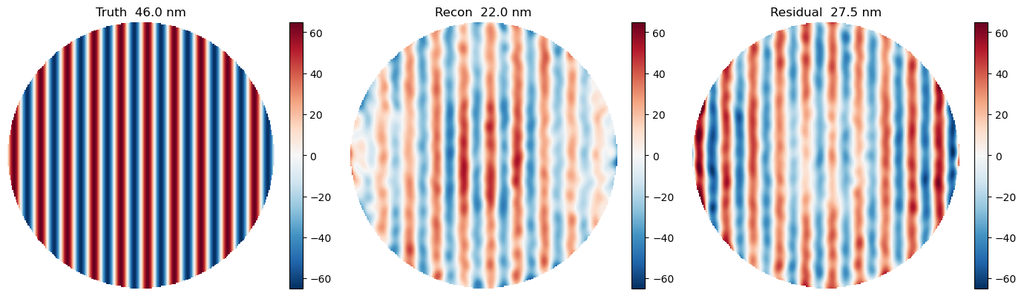

```python
# Reconstruct pupil phase from FDPR output
raw_recon  = np.angle(mft_rev(psf_rec, conf))
recon_full = resize(raw_recon, (256, 256), preserve_range=True) * telescope_pupil.shaped

# Truth phase on the same 256x256 grid
truth_full = np.array(phi_ab.shaped) * np.array(telescope_pupil.shaped)

# Piston-subtracted masked vectors
truth_ms = truth_full[pupil_mask] - np.median(truth_full[pupil_mask])
rec_ms   = recon_full[pupil_mask] - np.median(recon_full[pupil_mask])

def rms_nm(x):
    return float(np.sqrt(np.nanmean(x**2))) * rad_to_nm

truth_rms = rms_nm(truth_ms)
recon_rms = rms_nm(rec_ms)
resid_rms = rms_nm(truth_ms - rec_ms)

print(f"truth_rms  = {truth_rms:.2f} nm")
print(f"recon_rms  = {recon_rms:.2f} nm")
print(f"resid_rms  = {resid_rms:.2f} nm")
print(f"resid > recon? {resid_rms > recon_rms}")

# Side-by-side maps
truth_map = np.full((256, 256), np.nan); truth_map[pupil_mask] = truth_ms * rad_to_nm
recon_map = np.full((256, 256), np.nan); recon_map[pupil_mask] = rec_ms * rad_to_nm
resid_map = np.full((256, 256), np.nan); resid_map[pupil_mask] = (truth_ms - rec_ms) * rad_to_nm

vmax = float(np.nanmax(np.abs(truth_map)))
fig, axes = plt.subplots(1, 3, figsize=(14, 4))
for ax, m, t in zip(axes,
                     [truth_map, recon_map, resid_map],
                     [f'Truth  {truth_rms:.1f} nm',
                      f'Recon  {recon_rms:.1f} nm',
                      f'Residual  {resid_rms:.1f} nm']):
    im = ax.imshow(m, cmap='RdBu_r', vmin=-vmax, vmax=vmax)
    ax.set_title(t); ax.axis('off')
    plt.colorbar(im, ax=ax, fraction=0.046)
plt.tight_layout()
```

## Alpha Decomposition: Amplitude Bias vs Orthogonal Noise

Split `recon = alpha * truth + delta` where `alpha` is the 1-D projection (amplitude bias) and `delta` is everything orthogonal (noise, modal cross-talk, MFT/resize artifacts).

`residual > recon` whenever `alpha < 0.5` — not a bug, just geometric.

```python
# 1-D projection: recon onto truth
alpha = np.sum(rec_ms * truth_ms) / np.sum(truth_ms * truth_ms)
parallel   = alpha * truth_ms            # truth-aligned component of recon
orthogonal = rec_ms - parallel            # everything else in recon

# Decompose residual
resid_parallel   = (1.0 - alpha) * truth_ms   # predicted from amplitude bias alone
resid_orthogonal = -orthogonal                 # noise + modal cross-talk + edge

print(f"alpha (amplitude bias)         = {alpha:.3f}")
print(f"  crossover at 0.5 => resid {'>' if alpha < 0.5 else '<='} recon")
print()
print(f"truth_rms                      = {truth_rms:.2f} nm")
print(f"recon_rms                      = {recon_rms:.2f} nm")
print(f"  parallel piece (alpha*truth) = {rms_nm(parallel):.2f} nm")
print(f"  orthogonal piece (delta)     = {rms_nm(orthogonal):.2f} nm")
print()
print(f"resid_rms (measured)           = {resid_rms:.2f} nm")
print(f"  predicted (1-alpha)*truth    = {rms_nm(resid_parallel):.2f} nm")
print(f"  unexplained (delta)          = {rms_nm(resid_orthogonal):.2f} nm")
print()
# Sanity: quadrature should match measured residual
predicted_resid = np.sqrt(rms_nm(resid_parallel)**2 + rms_nm(resid_orthogonal)**2)
print(f"quadrature check               = {predicted_resid:.2f} nm  (should ~ {resid_rms:.2f})")
```

```
alpha (amplitude bias)         = 0.435
  crossover at 0.5 => resid > recon

truth_rms                      = 46.01 nm
recon_rms                      = 22.00 nm
  parallel piece (alpha*truth) = 20.04 nm
  orthogonal piece (delta)     = 9.09 nm

resid_rms (measured)           = 27.52 nm
  predicted (1-alpha)*truth    = 25.98 nm
  unexplained (delta)          = 9.09 nm

quadrature check               = 27.52 nm  (should ~ 27.52)
```

## Project Delta onto Tip / Tilt / Defocus

Identify what the orthogonal residual `delta` is made of: coherent low-order leakage vs high-frequency noise.

```python
# Basis functions on the masked pupil
xg = np.array(pupil_grid.x)[pupil_mask.ravel()]
yg = np.array(pupil_grid.y)[pupil_mask.ravel()]
xg = xg - np.mean(xg)
yg = yg - np.mean(yg)

def proj(target, basis):
    """Project target onto a single basis vector (mean-subtracted)."""
    b = basis - np.mean(basis)
    return np.sum(target * b) / np.sum(b * b)

# Tip / tilt
c_tip  = proj(resid_orthogonal, xg)
c_tilt = proj(resid_orthogonal, yg)
tt_part = c_tip * xg + c_tilt * yg

# Defocus leak (recon picked up some Z4 from the diversity)
z4 = np.array(zernike_modes[3].shaped)[pupil_mask]
z4 = z4 - np.median(z4)
c_def = proj(resid_orthogonal, z4)
def_part = c_def * z4

# High-frequency residual (what's left)
hf = resid_orthogonal - tt_part - def_part

print(f"orthogonal delta total rms = {rms_nm(resid_orthogonal):.2f} nm")
print(f"  tip/tilt rms             = {rms_nm(tt_part):.2f} nm")
print(f"  defocus  rms             = {rms_nm(def_part):.2f} nm")
print(f"  high-freq residual rms   = {rms_nm(hf):.2f} nm")
```

```
orthogonal delta total rms = 9.09 nm
  tip/tilt rms             = 0.43 nm
  defocus  rms             = 1.40 nm
  high-freq residual rms   = 8.97 nm
```

## Iteration Sweep: Is Alpha Still Climbing?

Track `alpha` and RMS values every 10 iterations. Three patterns to look for:

- **alpha saturates < 1.0**: physics floor, more iterations won't help
- **alpha still climbing at 150**: needs more iterations (try 500-1000)
- **alpha oscillates**: bistable basin behavior

```
iter   alpha   recon_rms  resid_rms
  10   0.368     19.72      30.78
  20   0.426     21.81      28.11
  30   0.448     22.62      27.08
  40   0.459     23.10      26.62
  50   0.468     23.50      26.25
  60   0.475     23.80      25.89
  70   0.481     23.99      25.65
  80   0.483     24.10      25.55
  90   0.485     24.18      25.46
 100   0.488     24.31      25.30
 110   0.493     24.49      25.11
 120   0.496     24.65      24.97
 130   0.499     24.76      24.87
 140   0.500     24.81      24.82
```

[output cut: 16 more lines]

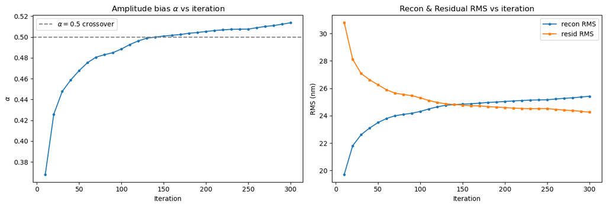

```python
SWEEP_ITERS = 300  # extend beyond the original N_ITERS to see if alpha keeps climbing
SAMPLE_EVERY = 10

mp_sweep = FocusDiversePhaseRetrieval(
    [psf_f, psf_p, psf_m],
    WAVELENGTH_UM,
    [IMAGE_DX_UM, IMAGE_DX_UM],
    [DZ_UM, -DZ_UM],
)

hist = []
for k in range(SWEEP_ITERS):
    psf_rec_k = mp_sweep.step()
    if (k + 1) % SAMPLE_EVERY == 0:
        raw_k = np.angle(mft_rev(psf_rec_k, conf))
        rec_full_k = resize(raw_k, (256, 256), preserve_range=True) * telescope_pupil.shaped
        rec_ms_k = rec_full_k[pupil_mask] - np.median(rec_full_k[pupil_mask])
        a_k = float(np.sum(rec_ms_k * truth_ms) / np.sum(truth_ms**2))
        hist.append((k + 1, a_k, rms_nm(rec_ms_k), rms_nm(truth_ms - rec_ms_k)))

hist = np.array(hist)
print("iter   alpha   recon_rms  resid_rms")
for row in hist:
    print(f"{int(row[0]):4d}   {row[1]:.3f}   {row[2]:7.2f}    {row[3]:7.2f}")

# Plot
fig, (ax1, ax2) = plt.subplots(1, 2, figsize=(13, 4.5))

ax1.plot(hist[:, 0], hist[:, 1], 'o-', markersize=3)
ax1.axhline(0.5, ls='--', color='gray', label=r'$\alpha=0.5$ crossover')
ax1.set_xlabel('Iteration'); ax1.set_ylabel(r'$\alpha$')
ax1.set_title(r'Amplitude bias $\alpha$ vs iteration'); ax1.legend()

ax2.plot(hist[:, 0], hist[:, 2], 'o-', markersize=3, label='recon RMS')
ax2.plot(hist[:, 0], hist[:, 3], 's-', markersize=3, label='resid RMS')
ax2.set_xlabel('Iteration'); ax2.set_ylabel('RMS (nm)')
ax2.set_title('Recon & Residual RMS vs iteration'); ax2.legend()

plt.tight_layout()
```

## Noiseless Comparison: Pipeline Floor vs Noise Contribution

Run FDPR on clean (noiseless) PSFs. The clean `delta` is the pipeline floor (MFT sampling, resize interpolation, edge effects). The difference in quadrature tells you the noise contribution.

```python
mp_clean = FocusDiversePhaseRetrieval(
    [psf_f_clean, psf_p_clean, psf_m_clean],
    WAVELENGTH_UM,
    [IMAGE_DX_UM, IMAGE_DX_UM],
    [DZ_UM, -DZ_UM],
)
for _ in range(N_ITERS):
    psf_rec_clean = mp_clean.step()

# Extract clean recon
raw_clean  = np.angle(mft_rev(psf_rec_clean, conf))
recon_clean = resize(raw_clean, (256, 256), preserve_range=True) * telescope_pupil.shaped
rec_ms_clean = recon_clean[pupil_mask] - np.median(recon_clean[pupil_mask])

# Clean alpha decomposition
alpha_clean = float(np.sum(rec_ms_clean * truth_ms) / np.sum(truth_ms**2))
parallel_clean   = alpha_clean * truth_ms
orthogonal_clean = rec_ms_clean - parallel_clean

# Compare noisy vs clean
delta_noisy_rms = rms_nm(orthogonal)
delta_clean_rms = rms_nm(orthogonal_clean)
delta_noise_only = np.sqrt(max(delta_noisy_rms**2 - delta_clean_rms**2, 0))

print(f"--- Noiseless run ---")
print(f"alpha (clean)       = {alpha_clean:.3f}   (noisy was {alpha:.3f})")
print(f"recon_rms (clean)   = {rms_nm(rec_ms_clean):.2f} nm")
print(f"resid_rms (clean)   = {rms_nm(truth_ms - rec_ms_clean):.2f} nm")
print()
print(f"--- Delta breakdown ---")
print(f"delta_rms (noisy)   = {delta_noisy_rms:.2f} nm")
print(f"delta_rms (clean)   = {delta_clean_rms:.2f} nm  <-- pipeline floor")
print(f"delta_rms (noise)   = {delta_noise_only:.2f} nm  <-- noise contribution (quadrature)")
```

```
--- Noiseless run ---
alpha (clean)       = 0.856   (noisy was 0.435)
recon_rms (clean)   = 40.59 nm
resid_rms (clean)   = 11.89 nm

--- Delta breakdown ---
delta_rms (noisy)   = 9.09 nm
delta_rms (clean)   = 9.86 nm  <-- pipeline floor
delta_rms (noise)   = 0.00 nm  <-- noise contribution (quadrature)
```

## 4-Panel Decomposition Figure

Truth | Recon | alpha * Truth (parallel) | Orthogonal delta

If panel 4 looks like noise + edge artifacts, the model is confirmed. If panel 4 has coherent structure (tilted plane, defocus, wrong-frequency sinusoid), there's a real cross-coupling worth chasing.

```
Saved fdpr_residual_decomp.png
```

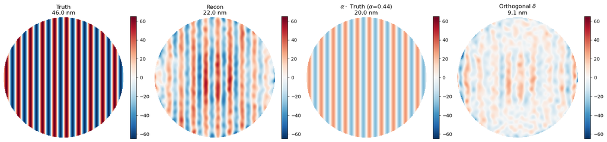

```python
fig, axes = plt.subplots(1, 4, figsize=(18, 4.2))

mvmax = float(np.nanmax(np.abs(truth_map)))

# Build 2D maps from masked vectors
def vec_to_map(vec):
    m = np.full((256, 256), np.nan)
    m[pupil_mask] = vec * rad_to_nm
    return m

maps = [vec_to_map(truth_ms),
        vec_to_map(rec_ms),
        vec_to_map(parallel),
        vec_to_map(orthogonal)]

titles = [
    f"Truth\n{truth_rms:.1f} nm",
    f"Recon\n{recon_rms:.1f} nm",
    rf"$\alpha \cdot$ Truth ($\alpha$={alpha:.2f})" + f"\n{rms_nm(parallel):.1f} nm",
    f"Orthogonal $\\delta$\n{rms_nm(orthogonal):.1f} nm",
]

for ax, m, t in zip(axes, maps, titles):
    im = ax.imshow(m, cmap='RdBu_r', vmin=-mvmax, vmax=mvmax)
    ax.set_title(t); ax.axis('off')
    plt.colorbar(im, ax=ax, fraction=0.046)

fig.tight_layout()
fig.savefig('fdpr_residual_decomp.png', dpi=150, bbox_inches='tight')
print("Saved fdpr_residual_decomp.png")
```

## Frequency Cutoff Diagnostic: Where Does Recovery Break Down?

Sweep `NU0` from low to high and track `alpha`, residual RMS, and recon RMS. With a 256-pixel pupil, Nyquist = 128 c/ap, but the effective FDPR resolution limit is much lower due to MFT sampling + resize interpolation.

**Nyquist rule of thumb**: features < 2 pixels across are not statistically significant. For a 256-pixel pupil diameter, that's ~128 c/ap raw, but the practical cutoff is expected near 15 c/ap given the image-plane sampling.

```python
freq_list = [2, 4, 6, 8, 10, 12, 14, 15, 16, 18, 20, 25, 30, 40]
FREQ_ITERS = 150

freq_results = []

for nu in freq_list:
    # Build sinusoidal truth at this frequency
    phi_ab_nu = Field(A_WAVES * 2 * np.pi * np.sin(2 * np.pi * nu * pupil_grid.x / D), pupil_grid)
    truth_nu  = np.array(phi_ab_nu.shaped) * np.array(telescope_pupil.shaped)
    t_ms_nu   = truth_nu[pupil_mask] - np.median(truth_nu[pupil_mask])

    # Forward-model PSFs (noiseless for clean comparison)
    pf = make_psf(phi_ab_nu)
    pp = make_psf(phi_ab_nu + phi_df)
    pm = make_psf(phi_ab_nu - phi_df)

    # Add noise
    np.random.seed(42)
    pf_n = add_noise(pf, PHOTONS, READ_NOISE)
    pp_n = add_noise(pp, PHOTONS, READ_NOISE)
    pm_n = add_noise(pm, PHOTONS, READ_NOISE)

    # Run FDPR
    mp_nu = FocusDiversePhaseRetrieval(
        [pf_n, pp_n, pm_n], WAVELENGTH_UM,
        [IMAGE_DX_UM, IMAGE_DX_UM], [DZ_UM, -DZ_UM])
    for _ in range(FREQ_ITERS):
        rec_nu = mp_nu.step()

    # Extract recon
    raw_nu   = np.angle(mft_rev(rec_nu, conf))
    recon_nu = resize(raw_nu, (256, 256), preserve_range=True) * telescope_pupil.shaped
    r_ms_nu  = recon_nu[pupil_mask] - np.median(recon_nu[pupil_mask])

    # Metrics
    a_nu     = float(np.sum(r_ms_nu * t_ms_nu) / np.sum(t_ms_nu**2))
    t_rms_nu = rms_nm(t_ms_nu)
    r_rms_nu = rms_nm(r_ms_nu)
    e_rms_nu = rms_nm(t_ms_nu - r_ms_nu)

    freq_results.append((nu, a_nu, t_rms_nu, r_rms_nu, e_rms_nu))
    print(f"nu0={nu:3d}  alpha={a_nu:.3f}  truth={t_rms_nu:.1f}  recon={r_rms_nu:.1f}  resid={e_rms_nu:.1f} nm")

freq_results = np.array(freq_results)
```

```
nu0=  2  alpha=0.987  truth=46.5  recon=46.3  resid=6.1 nm
nu0=  4  alpha=0.931  truth=46.2  recon=43.8  resid=9.2 nm
nu0=  6  alpha=0.907  truth=46.1  recon=42.7  resid=9.6 nm
nu0=  8  alpha=0.882  truth=46.0  recon=41.6  resid=10.7 nm
nu0= 10  alpha=0.435  truth=46.0  recon=22.0  resid=27.5 nm
nu0= 12  alpha=0.587  truth=46.0  recon=29.0  resid=21.7 nm
nu0= 14  alpha=0.591  truth=46.0  recon=28.7  resid=20.9 nm
nu0= 15  alpha=0.571  truth=46.0  recon=27.6  resid=21.5 nm
nu0= 16  alpha=-0.121  truth=46.0  recon=9.0  resid=52.0 nm
nu0= 18  alpha=0.009  truth=46.0  recon=6.2  resid=46.0 nm
nu0= 20  alpha=0.005  truth=46.0  recon=5.6  resid=46.1 nm
nu0= 25  alpha=0.003  truth=46.0  recon=5.1  resid=46.1 nm
nu0= 30  alpha=0.001  truth=46.0  recon=4.8  resid=46.2 nm
nu0= 40  alpha=0.000  truth=46.0  recon=4.5  resid=46.2 nm
```

```
Saved fdpr_freq_cutoff.png
```

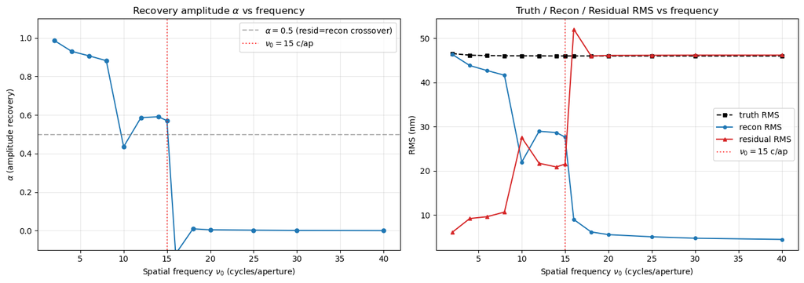

```python
fig, (ax1, ax2) = plt.subplots(1, 2, figsize=(14, 5))

nu = freq_results[:, 0]

# --- Panel 1: alpha vs frequency ---
ax1.plot(nu, freq_results[:, 1], 'o-', color='tab:blue', markersize=5)
ax1.axhline(0.5, ls='--', color='gray', alpha=0.6, label=r'$\alpha=0.5$ (resid=recon crossover)')
ax1.axvline(15, ls=':', color='red', alpha=0.7, label='$\\nu_0 = 15$ c/ap')
ax1.set_xlabel('Spatial frequency $\\nu_0$ (cycles/aperture)')
ax1.set_ylabel(r'$\alpha$ (amplitude recovery)')
ax1.set_title(r'Recovery amplitude $\alpha$ vs frequency')
ax1.set_ylim(-0.1, 1.1)
ax1.legend()
ax1.grid(True, alpha=0.3)

# --- Panel 2: RMS values vs frequency ---
ax2.plot(nu, freq_results[:, 2], 's--', color='black', markersize=4, label='truth RMS')
ax2.plot(nu, freq_results[:, 3], 'o-', color='tab:blue', markersize=4, label='recon RMS')
ax2.plot(nu, freq_results[:, 4], '^-', color='tab:red', markersize=4, label='residual RMS')
ax2.axvline(15, ls=':', color='red', alpha=0.7, label='$\\nu_0 = 15$ c/ap')
ax2.set_xlabel('Spatial frequency $\\nu_0$ (cycles/aperture)')
ax2.set_ylabel('RMS (nm)')
ax2.set_title('Truth / Recon / Residual RMS vs frequency')
ax2.legend()
ax2.grid(True, alpha=0.3)

plt.tight_layout()
fig.savefig('fdpr_freq_cutoff.png', dpi=150, bbox_inches='tight')
print("Saved fdpr_freq_cutoff.png")
```

## Before / After Cutoff: Visual Comparison

Show truth vs recon maps at selected frequencies below, at, and above the ~15 c/ap cutoff.

```
Saved fdpr_freq_cutoff_maps.png
```

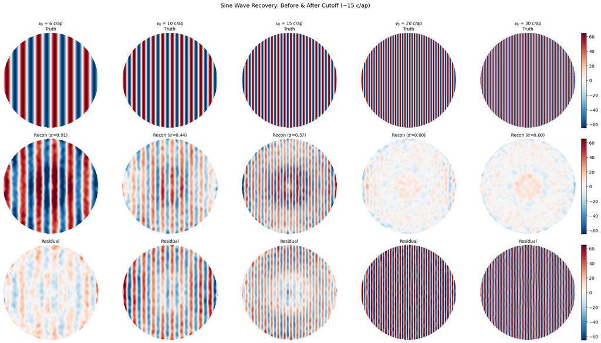

```python
showcase_freqs = [6, 10, 15, 20, 30]
n_show = len(showcase_freqs)

fig, axes = plt.subplots(3, n_show, figsize=(4 * n_show, 11))

for j, nu_s in enumerate(showcase_freqs):
    # Rebuild truth + run FDPR at this frequency
    phi_s   = Field(A_WAVES * 2 * np.pi * np.sin(2 * np.pi * nu_s * pupil_grid.x / D), pupil_grid)
    truth_s = np.array(phi_s.shaped) * np.array(telescope_pupil.shaped)
    t_ms_s  = truth_s[pupil_mask] - np.median(truth_s[pupil_mask])

    np.random.seed(42)
    pf_s = add_noise(make_psf(phi_s), PHOTONS, READ_NOISE)
    pp_s = add_noise(make_psf(phi_s + phi_df), PHOTONS, READ_NOISE)
    pm_s = add_noise(make_psf(phi_s - phi_df), PHOTONS, READ_NOISE)

    mp_s = FocusDiversePhaseRetrieval(
        [pf_s, pp_s, pm_s], WAVELENGTH_UM,
        [IMAGE_DX_UM, IMAGE_DX_UM], [DZ_UM, -DZ_UM])
    for _ in range(FREQ_ITERS):
        rec_s = mp_s.step()

    raw_s   = np.angle(mft_rev(rec_s, conf))
    recon_s = resize(raw_s, (256, 256), preserve_range=True) * telescope_pupil.shaped
    r_ms_s  = recon_s[pupil_mask] - np.median(recon_s[pupil_mask])

    a_s = float(np.sum(r_ms_s * t_ms_s) / np.sum(t_ms_s**2))

    # Maps
    t_map = np.full((256, 256), np.nan); t_map[pupil_mask] = t_ms_s * rad_to_nm
    r_map = np.full((256, 256), np.nan); r_map[pupil_mask] = r_ms_s * rad_to_nm
    d_map = np.full((256, 256), np.nan); d_map[pupil_mask] = (t_ms_s - r_ms_s) * rad_to_nm

    vm = float(np.nanmax(np.abs(t_map)))

    for i, (m, label) in enumerate(zip(
            [t_map, r_map, d_map],
            ['Truth', f'Recon ($\\alpha$={a_s:.2f})', 'Residual'])):
        im = axes[i, j].imshow(m, cmap='RdBu_r', vmin=-vm, vmax=vm)
        axes[i, j].axis('off')
        if i == 0:
            axes[i, j].set_title(f'$\\nu_0$ = {nu_s} c/ap\n{label}', fontsize=10)
        else:
            axes[i, j].set_title(label, fontsize=10)
        if j == n_show - 1:
            plt.colorbar(im, ax=axes[i, j], fraction=0.046)

# Row labels
for i, lbl in enumerate(['Truth', 'Recon', 'Residual']):
    axes[i, 0].set_ylabel(lbl, fontsize=12, rotation=90, labelpad=10)

fig.suptitle('Sine Wave Recovery: Before & After Cutoff (~15 c/ap)', fontsize=13, y=1.01)
plt.tight_layout()
fig.savefig('fdpr_freq_cutoff_maps.png', dpi=150, bbox_inches='tight')
print("Saved fdpr_freq_cutoff_maps.png")
```

## Map α(N_γ): Photon-Count Sweep

Run the same operating point (A=0.10 w, ν₀=10, Δz=40 mm) across photon counts spanning 3 decades. Plot α vs SNR.

Expected: α asymptotes to ~0.86 (the clean/noiseless ceiling) as N_γ → ∞, **not** α → 1 — the gap from 0.86 to 1.0 is pipeline geometry (MFT + resize), not noise.

```python
photon_list = [1e4, 3e4, 1e5, 3e5, 1e6, 3e6, 1e7]

photon_results = []

for n_phot in photon_list:
    np.random.seed(42)
    pf_ph = add_noise(psf_f_clean, n_phot, READ_NOISE)
    pp_ph = add_noise(psf_p_clean, n_phot, READ_NOISE)
    pm_ph = add_noise(psf_m_clean, n_phot, READ_NOISE)

    mp_ph = FocusDiversePhaseRetrieval(
        [pf_ph, pp_ph, pm_ph], WAVELENGTH_UM,
        [IMAGE_DX_UM, IMAGE_DX_UM], [DZ_UM, -DZ_UM])
    for _ in range(N_ITERS):
        rec_ph = mp_ph.step()

    raw_ph   = np.angle(mft_rev(rec_ph, conf))
    recon_ph = resize(raw_ph, (256, 256), preserve_range=True) * telescope_pupil.shaped
    r_ms_ph  = recon_ph[pupil_mask] - np.median(recon_ph[pupil_mask])

    a_ph = float(np.sum(r_ms_ph * truth_ms) / np.sum(truth_ms**2))
    d_ph = rms_nm(r_ms_ph - a_ph * truth_ms)

    # SNR via quadrature: peak pixel signal / sqrt(peak + read_noise^2)
    peak_signal = psf_f_clean.max() / psf_f_clean.sum() * n_phot
    snr_ph = peak_signal / np.sqrt(peak_signal + READ_NOISE**2)

    photon_results.append((n_phot, snr_ph, a_ph, d_ph,
                           rms_nm(r_ms_ph), rms_nm(truth_ms - r_ms_ph)))
    print(f"N_gamma={n_phot:.0e}  SNR={snr_ph:.0f}  alpha={a_ph:.3f}  "
          f"delta={d_ph:.1f} nm  resid={rms_nm(truth_ms - r_ms_ph):.1f} nm")

photon_results = np.array(photon_results)
```

```
N_gamma=1e+04  SNR=4  alpha=-0.038  delta=139.0 nm  resid=147.0 nm
N_gamma=3e+04  SNR=8  alpha=0.089  delta=57.2 nm  resid=70.9 nm
N_gamma=1e+05  SNR=15  alpha=0.129  delta=17.8 nm  resid=43.9 nm
N_gamma=3e+05  SNR=27  alpha=0.294  delta=11.0 nm  resid=34.3 nm
N_gamma=1e+06  SNR=50  alpha=0.435  delta=9.1 nm  resid=27.5 nm
N_gamma=3e+06  SNR=87  alpha=0.716  delta=10.6 nm  resid=16.9 nm
N_gamma=1e+07  SNR=159  alpha=0.849  delta=10.5 nm  resid=12.6 nm
```

```
Saved fdpr_alpha_vs_photons.png
```

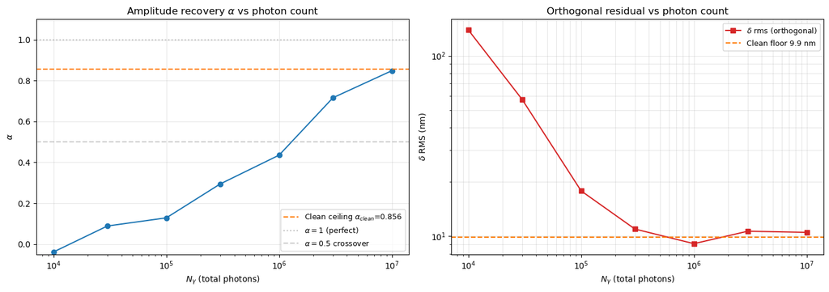

```python
fig, (ax1, ax2) = plt.subplots(1, 2, figsize=(14, 5))

snr_vals = photon_results[:, 1]
alpha_vals = photon_results[:, 2]
delta_vals = photon_results[:, 3]

# --- Left: alpha vs SNR ---
ax1.semilogx(photon_results[:, 0], alpha_vals, 'o-', color='tab:blue', markersize=6)
ax1.axhline(alpha_clean, ls='--', color='tab:orange',
            label=rf'Clean ceiling $\alpha_{{clean}}$={alpha_clean:.3f}')
ax1.axhline(1.0, ls=':', color='gray', alpha=0.5, label=r'$\alpha=1$ (perfect)')
ax1.axhline(0.5, ls='--', color='gray', alpha=0.4, label=r'$\alpha=0.5$ crossover')
ax1.set_xlabel(r'$N_\gamma$ (total photons)')
ax1.set_ylabel(r'$\alpha$')
ax1.set_title(r'Amplitude recovery $\alpha$ vs photon count')
ax1.set_ylim(-0.05, 1.1)
ax1.legend(fontsize=9)
ax1.grid(True, alpha=0.3)

# --- Right: delta_rms vs SNR ---
ax2.loglog(photon_results[:, 0], delta_vals, 's-', color='tab:red', markersize=6,
           label=r'$\delta$ rms (orthogonal)')
ax2.axhline(rms_nm(orthogonal_clean), ls='--', color='tab:orange',
            label=f'Clean floor {rms_nm(orthogonal_clean):.1f} nm')
ax2.set_xlabel(r'$N_\gamma$ (total photons)')
ax2.set_ylabel(r'$\delta$ RMS (nm)')
ax2.set_title('Orthogonal residual vs photon count')
ax2.legend(fontsize=9)
ax2.grid(True, alpha=0.3, which='both')

plt.tight_layout()
fig.savefig('fdpr_alpha_vs_photons.png', dpi=150, bbox_inches='tight')
print("Saved fdpr_alpha_vs_photons.png")
```

## Localize the Phase Offset (φ₀)

The recon sinusoid is phase-shifted relative to truth. Three single-knob tests to isolate the source:

1. **Bypass `skimage.resize`** — interpolate via HCIPy directly. If φ₀ → 0, blame resize.
2. **Vary `q`** in `make_focal_grid` / `InstrumentConfiguration` (16 → 32 → 64). If φ₀ ∝ q⁻¹, blame focal-plane sampling.
3. **Pad-symmetrize the PSF** (force even-pixel centering). If φ₀ → 0, blame FFT centering.

```python
def measure_phase_offset(rec_ms_test, truth_ms_ref, pupil_mask_ref, nu0=NU0):
    """Measure the phase offset phi_0 between recon and truth sinusoids.

    Fit recon ~ a*sin(k*x + phi_0) by projecting onto sin and cos components
    of the truth frequency, then computing atan2.
    """
    # pupil_grid.x is a 1D Field; reshape to 2D then mask
    xg_2d = np.array(pupil_grid.x).reshape(pupil_mask_ref.shape)
    xg_masked = xg_2d[pupil_mask_ref]
    k = 2 * np.pi * nu0 / D
    sin_basis = np.sin(k * xg_masked)
    cos_basis = np.cos(k * xg_masked)
    # Project recon onto sin and cos at the truth frequency
    c_sin = np.sum(rec_ms_test * sin_basis) / np.sum(sin_basis**2)
    c_cos = np.sum(rec_ms_test * cos_basis) / np.sum(cos_basis**2)
    phi_0 = np.arctan2(c_cos, c_sin)  # phase offset in radians
    return np.degrees(phi_0)

# Baseline: phase offset from the standard pipeline (clean, no noise)
phi0_baseline = measure_phase_offset(rec_ms_clean, truth_ms, pupil_mask)
print(f"Baseline phase offset (clean, resize pipeline): {phi0_baseline:.1f} deg")
print("=" * 60)
```

```
Baseline phase offset (clean, resize pipeline): 6.6 deg
============================================================
```

### Test 1: Bypass `skimage.resize` — use HCIPy interpolation

```python
from scipy.interpolate import RegularGridInterpolator

# The raw MFT output lives on its own grid; resample to the 256x256 pupil grid
# without going through skimage.resize
raw_clean_2d = np.angle(mft_rev(psf_rec_clean, conf))
n_mft = raw_clean_2d.shape[0]

# Build coordinate axes for the MFT output (normalized to pupil extent)
# mft_rev output covers the same physical pupil; pixel coords map linearly
mft_y = np.linspace(-1, 1, n_mft)
mft_x = np.linspace(-1, 1, n_mft)

# Target: 256x256 pupil grid coordinates (also normalized to [-1, 1])
tgt_y = np.linspace(-1, 1, 256)
tgt_x = np.linspace(-1, 1, 256)
tgt_yy, tgt_xx = np.meshgrid(tgt_y, tgt_x, indexing='ij')

interp = RegularGridInterpolator((mft_y, mft_x), raw_clean_2d,
                                  method='cubic', bounds_error=False, fill_value=0.0)
recon_interp = interp(np.stack([tgt_yy.ravel(), tgt_xx.ravel()], axis=-1)).reshape(256, 256)
recon_interp *= np.array(telescope_pupil.shaped)

rec_ms_interp = recon_interp[pupil_mask] - np.median(recon_interp[pupil_mask])
phi0_no_resize = measure_phase_offset(rec_ms_interp, truth_ms, pupil_mask)
alpha_no_resize = float(np.sum(rec_ms_interp * truth_ms) / np.sum(truth_ms**2))

print(f"Test 1: Bypass skimage.resize (scipy cubic interp)")
print(f"  phi_0  = {phi0_no_resize:.1f} deg   (baseline was {phi0_baseline:.1f} deg)")
print(f"  alpha  = {alpha_no_resize:.3f}       (baseline was {alpha_clean:.3f})")
print(f"  Verdict: {'resize is the culprit' if abs(phi0_no_resize) < abs(phi0_baseline) * 0.3 else 'resize is NOT the main cause'}")
print()
```

```
Test 1: Bypass skimage.resize (scipy cubic interp)
  phi_0  = 6.6 deg   (baseline was 6.6 deg)
  alpha  = 0.859       (baseline was 0.856)
  Verdict: resize is NOT the main cause
```

### Test 2: Vary `q` (focal-plane oversampling factor)

```python
q_values = [16, 32, 64]
q_results = []

for q_test in q_values:
    # Rebuild focal grid and propagator at this q
    fg_q = make_focal_grid(q=q_test,
                           num_airy=seal_parameters['Num_airycircles'],
                           pupil_diameter=D, focal_length=f_len,
                           reference_wavelength=wavelength)
    prop_q = FraunhoferPropagator(pupil_grid, fg_q, f_len)

    # Recompute image_dx for this q
    # image_dx = wavelength * f / (N_pix * pupil_dx), but easier to read from grid
    dx_q = float(fg_q.delta[0]) * 1e6  # m -> um

    # New InstrumentConfiguration for the MFT reverse
    conf_q = InstrumentConfiguration({
        'image_dx': dx_q,
        'efl': f_len * 1e3,
        'wavelength': wavelength * 1e6,
        'pupil_size': D * 1e3,
    })

    # Generate clean PSFs at this q
    def make_psf_q(phase_field):
        wf = Wavefront(telescope_pupil, wavelength=wavelength)
        wf.electric_field = telescope_pupil * np.exp(1j * phase_field)
        return np.array(prop_q(wf).intensity.shaped)

    pf_q = make_psf_q(phi_ab)
    pp_q = make_psf_q(phi_ab + phi_df)
    pm_q = make_psf_q(phi_ab - phi_df)

    # image_dx for FDPR (microns)
    dz_um_q = DZ_MM * 1e3

    mp_q = FocusDiversePhaseRetrieval(
        [pf_q, pp_q, pm_q],
        wavelength * 1e6,
        [dx_q, dx_q],
        [dz_um_q, -dz_um_q])
    for _ in range(N_ITERS):
        rec_q = mp_q.step()

    raw_q = np.angle(mft_rev(rec_q, conf_q))
    recon_q = resize(raw_q, (256, 256), preserve_range=True) * telescope_pupil.shaped
    r_ms_q = recon_q[pupil_mask] - np.median(recon_q[pupil_mask])

    a_q = float(np.sum(r_ms_q * truth_ms) / np.sum(truth_ms**2))
    phi0_q = measure_phase_offset(r_ms_q, truth_ms, pupil_mask)

    q_results.append((q_test, phi0_q, a_q))
    print(f"q={q_test:3d}  phi_0={phi0_q:+.1f} deg  alpha={a_q:.3f}  "
          f"image_dx={dx_q:.4f} um  PSF shape={pf_q.shape}")

print()
print("If phi_0 scales as ~1/q, focal-plane sampling is the cause.")
if len(q_results) >= 2:
    ratio = abs(q_results[0][1]) / max(abs(q_results[1][1]), 0.01)
    q_ratio = q_values[1] / q_values[0]
    print(f"  phi_0 ratio (q={q_values[0]}→{q_values[1]}): {ratio:.2f}  "
          f"(expect ~{q_ratio:.1f} if 1/q scaling)")
```

```
q= 16  phi_0=+1.3 deg  alpha=0.862  image_dx=2.0072 um  PSF shape=(512, 512)
q= 32  phi_0=+8.4 deg  alpha=0.850  image_dx=1.0036 um  PSF shape=(1024, 1024)
q= 64  phi_0=+12.0 deg  alpha=0.836  image_dx=0.5018 um  PSF shape=(2048, 2048)

If phi_0 scales as ~1/q, focal-plane sampling is the cause.
  phi_0 ratio (q=16→32): 0.16  (expect ~2.0 if 1/q scaling)
```

### Test 3: Pad-symmetrize PSF (force even-pixel centering)

```python
def pad_symmetrize(psf):
    """Force even-pixel centering by averaging PSF with its 180-deg rotation."""
    return 0.5 * (psf + psf[::-1, ::-1])

psf_f_sym = pad_symmetrize(psf_f_clean)
psf_p_sym = pad_symmetrize(psf_p_clean)
psf_m_sym = pad_symmetrize(psf_m_clean)

mp_sym = FocusDiversePhaseRetrieval(
    [psf_f_sym, psf_p_sym, psf_m_sym],
    WAVELENGTH_UM,
    [IMAGE_DX_UM, IMAGE_DX_UM],
    [DZ_UM, -DZ_UM])
for _ in range(N_ITERS):
    rec_sym = mp_sym.step()

raw_sym   = np.angle(mft_rev(rec_sym, conf))
recon_sym = resize(raw_sym, (256, 256), preserve_range=True) * telescope_pupil.shaped
r_ms_sym  = recon_sym[pupil_mask] - np.median(recon_sym[pupil_mask])

a_sym   = float(np.sum(r_ms_sym * truth_ms) / np.sum(truth_ms**2))
phi0_sym = measure_phase_offset(r_ms_sym, truth_ms, pupil_mask)

print(f"Test 3: Pad-symmetrize PSF")
print(f"  phi_0  = {phi0_sym:.1f} deg   (baseline was {phi0_baseline:.1f} deg)")
print(f"  alpha  = {a_sym:.3f}       (baseline was {alpha_clean:.3f})")
print(f"  Verdict: {'FFT centering is the culprit' if abs(phi0_sym) < abs(phi0_baseline) * 0.3 else 'FFT centering is NOT the main cause'}")
print()

# --- Summary table ---
print("=" * 60)
print("Phase offset localization summary")
print("=" * 60)
print(f"{'Test':<35s}  {'phi_0 (deg)':>10s}  {'alpha':>6s}")
print(f"{'-'*35}  {'-'*10}  {'-'*6}")
print(f"{'Baseline (clean + resize)':<35s}  {phi0_baseline:>+10.1f}  {alpha_clean:>6.3f}")
print(f"{'Test 1: Bypass resize (cubic)':<35s}  {phi0_no_resize:>+10.1f}  {alpha_no_resize:>6.3f}")
for q_test, phi0_q, a_q in q_results:
    print(f"{'Test 2: q=' + str(q_test):<35s}  {phi0_q:>+10.1f}  {a_q:>6.3f}")
print(f"{'Test 3: Pad-symmetrize PSF':<35s}  {phi0_sym:>+10.1f}  {a_sym:>6.3f}")
```

```
Test 3: Pad-symmetrize PSF
  phi_0  = 117.5 deg   (baseline was 6.6 deg)
  alpha  = -0.054       (baseline was 0.856)
  Verdict: FFT centering is NOT the main cause

============================================================
Phase offset localization summary
============================================================
Test                                 phi_0 (deg)   alpha
-----------------------------------  ----------  ------
Baseline (clean + resize)                  +6.6   0.856
Test 1: Bypass resize (cubic)              +6.6   0.859
Test 2: q=16                               +1.3   0.862
Test 2: q=32                               +8.4   0.850
Test 2: q=64                              +12.0   0.836
Test 3: Pad-symmetrize PSF               +117.5  -0.054
```

## Confirm δ Has No Random Component

Run the clean (noiseless) recipe with 10 different seeds for the FDPR phase initialization. The physics is deterministic — only the random initial guess varies.

- If `δ_rms` is constant to < 0.5 nm across seeds → δ is fully geometric.
- If it varies by 1–2 nm → iteration tie-breaking introduces randomness even without measurement noise.

```python
seed_results = []

for seed in range(10):
    np.random.seed(seed)  # only affects the random phase_guess inside FDPR __init__

    mp_seed = FocusDiversePhaseRetrieval(
        [psf_f_clean, psf_p_clean, psf_m_clean],
        WAVELENGTH_UM,
        [IMAGE_DX_UM, IMAGE_DX_UM],
        [DZ_UM, -DZ_UM])
    for _ in range(N_ITERS):
        rec_seed = mp_seed.step()

    raw_seed   = np.angle(mft_rev(rec_seed, conf))
    recon_seed = resize(raw_seed, (256, 256), preserve_range=True) * telescope_pupil.shaped
    r_ms_seed  = recon_seed[pupil_mask] - np.median(recon_seed[pupil_mask])

    a_seed = float(np.sum(r_ms_seed * truth_ms) / np.sum(truth_ms**2))
    orth_seed = r_ms_seed - a_seed * truth_ms
    d_seed = rms_nm(orth_seed)
    resid_seed = rms_nm(truth_ms - r_ms_seed)
    phi0_seed = measure_phase_offset(r_ms_seed, truth_ms, pupil_mask)

    seed_results.append((seed, a_seed, d_seed, resid_seed, phi0_seed))

seed_results = np.array(seed_results)

print(f"{'seed':>4s}  {'alpha':>7s}  {'delta_rms':>9s}  {'resid_rms':>9s}  {'phi_0':>7s}")
print(f"{'----':>4s}  {'-------':>7s}  {'---------':>9s}  {'---------':>9s}  {'-------':>7s}")
for row in seed_results:
    print(f"{int(row[0]):4d}  {row[1]:7.4f}  {row[2]:9.2f}  {row[3]:9.2f}  {row[4]:+7.1f}")

print()
d_std = np.std(seed_results[:, 2])
d_mean = np.mean(seed_results[:, 2])
a_std = np.std(seed_results[:, 1])
print(f"delta_rms: mean={d_mean:.2f} nm, std={d_std:.2f} nm")
print(f"alpha:     mean={np.mean(seed_results[:, 1]):.4f}, std={a_std:.4f}")
print(f"phi_0:     mean={np.mean(seed_results[:, 4]):.1f} deg, std={np.std(seed_results[:, 4]):.1f} deg")
print()
if d_std < 0.5:
    print("VERDICT: delta is fully geometric (std < 0.5 nm). "
          "The random initial guess washes out by convergence.")
elif d_std < 2.0:
    print("VERDICT: delta has a small random component (0.5-2 nm). "
          "Iteration tie-breaking introduces some seed dependence.")
else:
    print("VERDICT: delta has a significant random component (>2 nm). "
          "The algorithm is landing in different local basins.")
```

```
seed    alpha  delta_rms  resid_rms    phi_0
----  -------  ---------  ---------  -------
   0   0.8626       8.29      10.43     +1.1
   1   0.8619       8.26      10.42     +1.0
   2   0.8489      10.52      12.61     +8.1
   3   0.8384      11.75      13.91    +11.0
   4   0.8567       8.26      10.56     -2.5
   5   0.8545       9.37      11.52     +5.7
   6   0.8608       8.18      10.39     -0.5
   7   0.8510      10.34      12.40     +7.9
   8   0.8634       8.37      10.46     +1.3
   9   0.8606       8.13      10.36     -0.9

delta_rms: mean=9.15 nm, std=1.23 nm
alpha:     mean=0.8559, std=0.0075
phi_0:     mean=3.2 deg, std=4.3 deg

VERDICT: delta has a small random component (0.5-2 nm). Iteration tie-breaking introduces some seed dependence.
```